# VLM Wrong Predictions: attr_decking_material

**Model:** DINOv3 + Logistic Regression  
**Attribute:** attr_decking_material  
**Wrong assets:** 75 of 1774 (4.2% asset-level error rate)

Asset 48341 1 image

Predicted: Timber (conf: N/A)

Actual: Steel

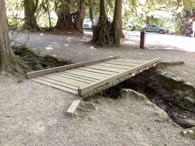

10732__AST_EX_20210805_150527.jpeg

Asset 49664 2 images

Predicted: Timber (conf: N/A)

Actual: Steel

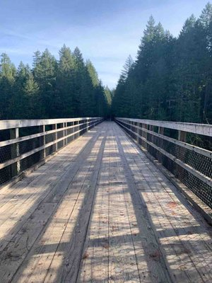

35820__AST_EX_20220211_111532.jpeg

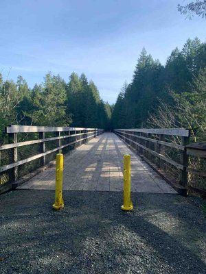

35818__AST_EX_20220211_111547.jpeg

Asset 51524 1 image

Predicted: Timber (conf: N/A)

Actual: Steel

[figure not shown]

16914__AST_EX_20210820_142024.jpeg

Asset 51798 7 images

Predicted: Steel (conf: N/A)

Actual: Concrete

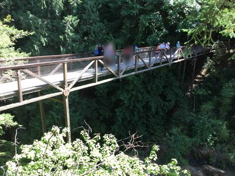

6759__AST_EX_20210719_112242.jpeg

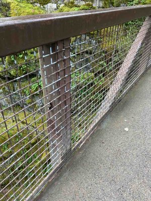

77873__AST_EX_20241128_121359.jpeg

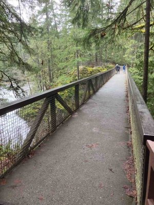

77868__AST_EX_20241128_121253.jpeg

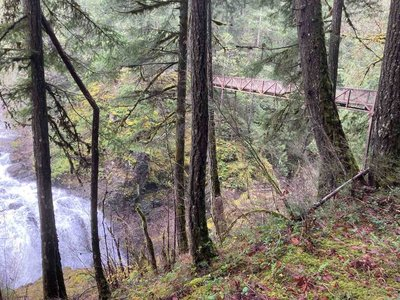

77886__AST_EX_20241128_121213.jpeg

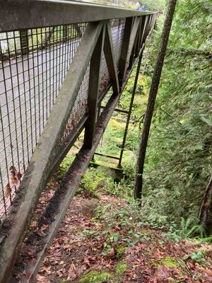

77875__AST_EX_20241128_121243.jpeg

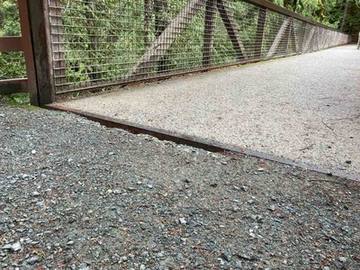

77898__AST_EX_20241128_121412.jpeg

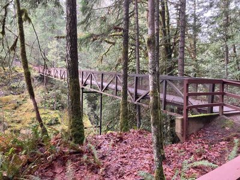

77896__AST_EX_20241128_121149.jpeg

Asset 55635 1 image

Predicted: Asphalt (conf: N/A)

Actual: Concrete

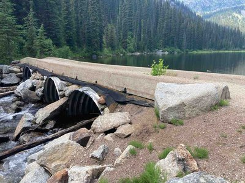

57138__AST_EX_20220729_121246.jpeg

Asset 63068 1 image

Predicted: Steel (conf: N/A)

Actual: Timber

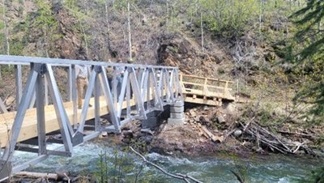

87457__Picture1.jpg

Asset 65608 2 images

Predicted: Timber (conf: N/A)

Actual: Concrete

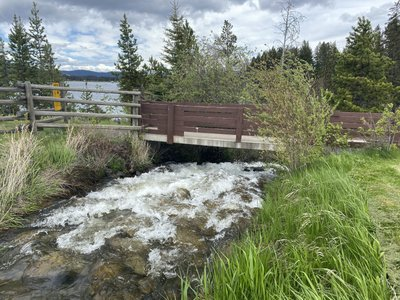

45622__IMG_0192.JPG

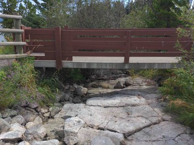

60899__MI_20220823_121454.jpg

Asset 66920 1 image

Predicted: Steel (conf: N/A)

Actual: Timber

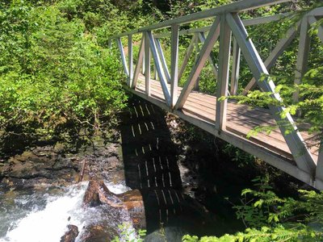

64861__AST_IM_20220717_132815.jpeg

Asset 102344 1 image

Predicted: Steel (conf: N/A)

Actual: Timber

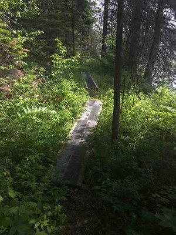

46488__AST_IM_20220615_115431.jpeg

Asset 104858 1 image

Predicted: Timber (conf: N/A)

Actual: Asphalt

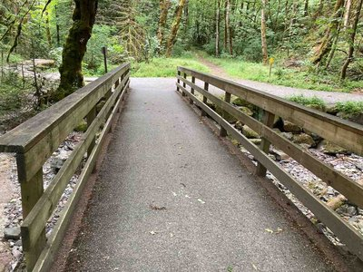

50120__AST_IM_20220628_105214.jpeg

Asset 119774 1 image

Predicted: Timber (conf: N/A)

Actual: Steel

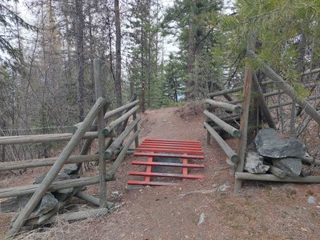

68016__MI_20240424_082404.jpg

Asset 123655 2 images

Predicted: Timber (conf: N/A)

Actual: Steel

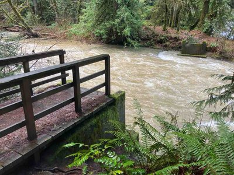

78143__AST_IM_20241218_122442.jpeg

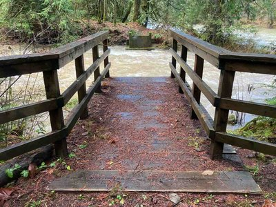

78151__AST_IM_20241218_122432.jpeg

Asset 126801 3 images

Predicted: Steel (conf: N/A)

Actual: Aluminum

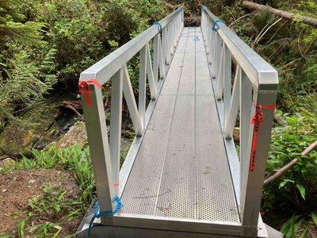

85645__AST_IM_20250730_143332.jpeg

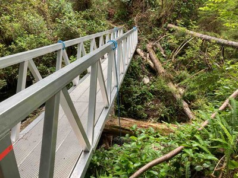

85662__AST_IM_20250730_143348.jpeg

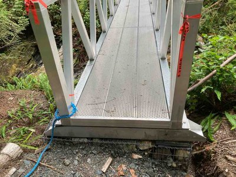

85646__AST_IM_20250730_143340.jpeg

Asset 126803 1 image

Predicted: Steel (conf: N/A)

Actual: Aluminum

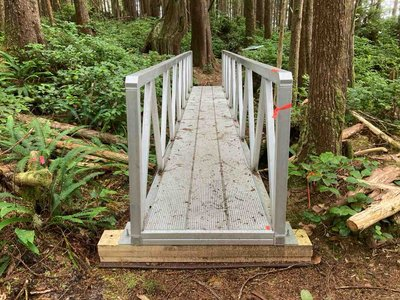

85659__AST_IM_20250730_145101.jpeg

Asset 51549 2 images

Predicted: Timber (conf: N/A)

Actual: Steel

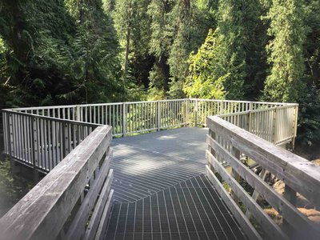

16896__AST_EX_20210820_124957.jpeg

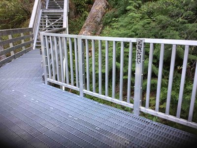

16899__AST_EX_20210820_124439.jpeg

Asset 51551 1 image

Predicted: Timber (conf: N/A)

Actual: Concrete

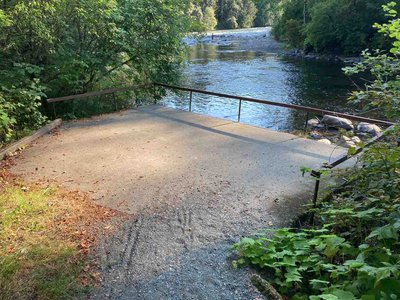

61176__AST_EX_20220824_093217.jpeg

Asset 54507 1 image

Predicted: Timber (conf: N/A)

Actual: Concrete

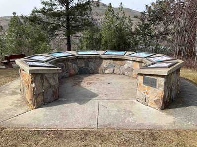

37393__AST_EX_20220324_141256.jpeg

Asset 67796 1 image

Predicted: Timber (conf: N/A)

Actual: Concrete

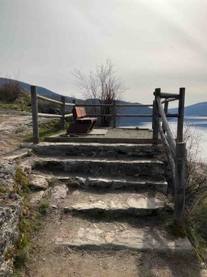

37371__AST_EX_20220324_145536.jpeg

Asset 105246 1 image

Predicted: Steel (conf: N/A)

Actual: Timber

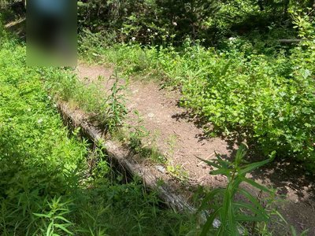

84459__AST_EX_20250704_130306.jpeg

Asset 120665 1 image

Predicted: Timber (conf: N/A)

Actual: Steel

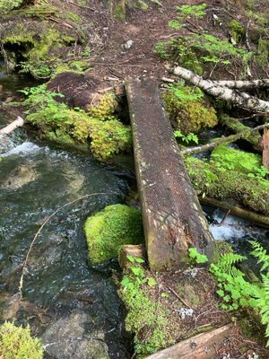

69762__AST_IM_20240606_091232.jpeg

Asset 121730 1 image

Predicted: Timber (conf: N/A)

Actual: Steel

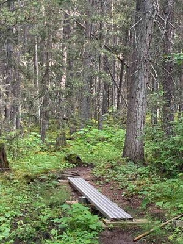

72508__AST_IM_20240813_102517.jpeg

Asset 81881 1 image

Predicted: Steel (conf: N/A)

Actual: Timber

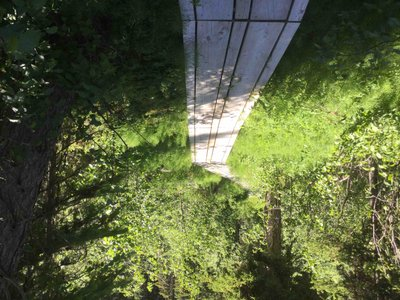

2851__AST_IM_20210627_113032.jpeg

Asset 52457 1 image

Predicted: Steel (conf: N/A)

Actual: Aluminum

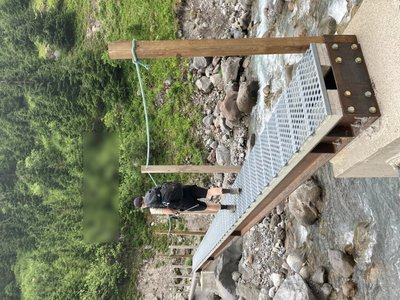

77956__IMG_3182.jpg

Asset 58160 10 images

Predicted: Timber (conf: N/A)

Actual: Steel

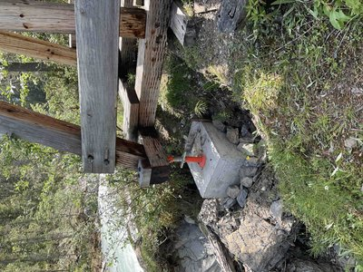

8158__AST_EX_20210727_134921.jpeg

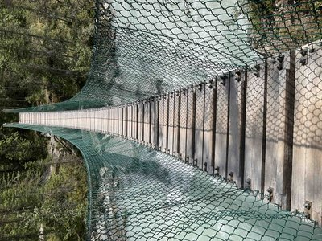

8159__AST_EX_20210727_134836.jpeg

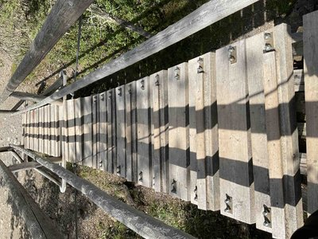

8160__AST_EX_20210727_134827.jpeg

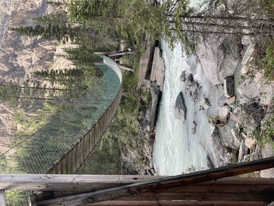

8161__AST_EX_20210727_134646.jpeg

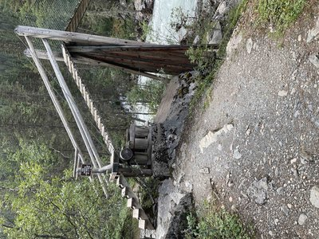

8162__AST_EX_20210727_134633.jpeg

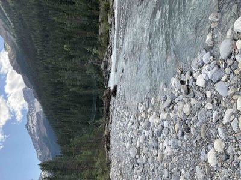

8163__AST_EX_20210727_133917.jpeg

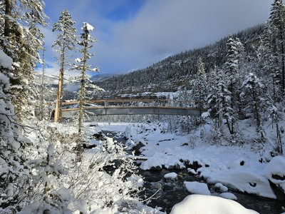

67242__20231125_112131.jpg

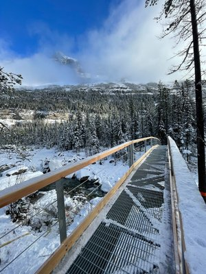

67243__IMG_2462.JPG

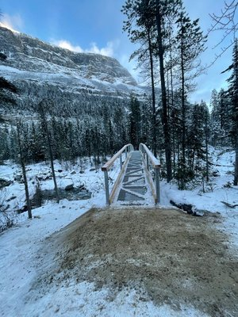

67244__IMG_2474.JPG

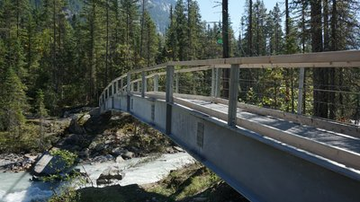

79620__New_Whitehorn_bridge.JPG

Asset 64643 1 image

Predicted: Timber (conf: N/A)

Actual: Steel

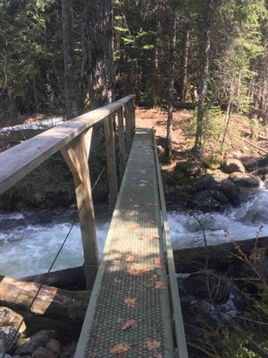

47085__AST_EX_20220617_123258.jpeg

Asset 65497 2 images

Predicted: Steel (conf: N/A)

Actual: Timber

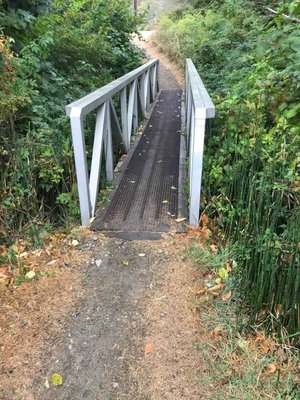

20022__AST_EX_20210904_141825.jpeg

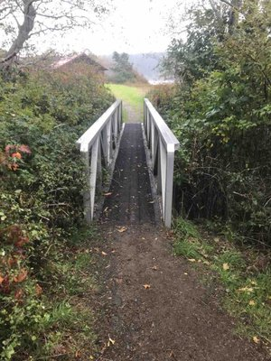

26366__AST_EX_20211012_113507.jpeg

Asset 102347 1 image

Predicted: Steel (conf: N/A)

Actual: Timber

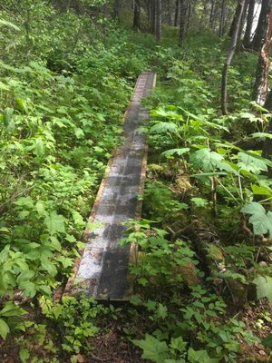

46507__AST_IM_20220615_115858.jpeg

Asset 113125 4 images

Predicted: Steel (conf: N/A)

Actual: Timber

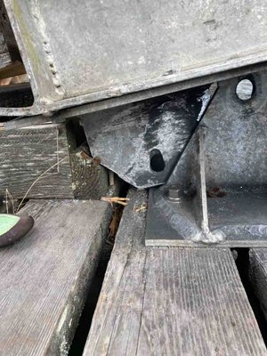

61435__AST_IM_20220826_095740.jpeg

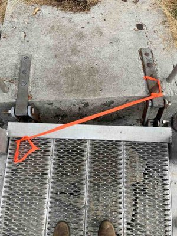

61438__AST_IM_20220826_104550.jpeg

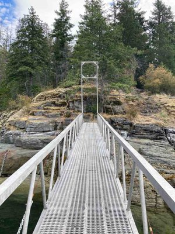

61440__AST_IM_20220826_095727.jpeg

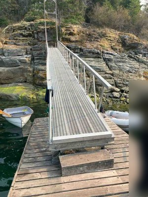

87467__AST_EX_20250905_110148.jpeg

Asset 117720 1 image

Predicted: Asphalt (conf: N/A)

Actual: Timber

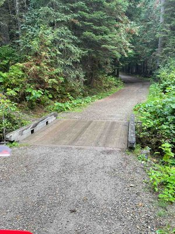

66054__AST_IM_20230903_093825.jpeg

Asset 121618 4 images

Predicted: Timber (conf: N/A)

Actual: Aluminum

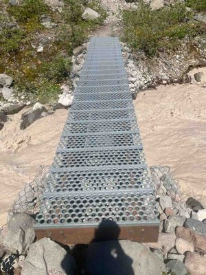

72114__AST_IM_20240803_115637.jpeg

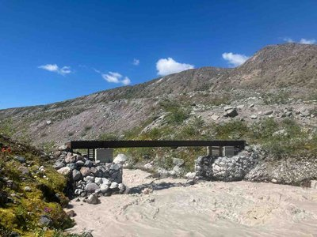

72119__AST_IM_20240803_115627.jpeg

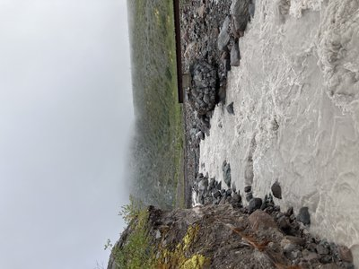

89897__Channel_view_lower_water.jpeg

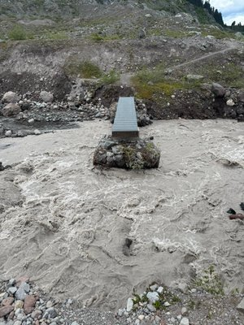

89898__Bridge_elfin_side_-_high_water.jpeg